# Tutorial 3 (extended)

## Tutorial 3 (extended version)

Credit: Yen-Ling Kuo and Eugenio Piasini for the Brains, Minds and Machines summer course 2018.

**PyTorch installation guide**

- To install PyTorch via Anaconda, use the following conda command:

*conda install pytorch torchvision -c pytorch*

- To install PyTorch via pip, use the following two command (for Python 3.x version):

*pip3 install torch torchvision*

**Note**: For more information, follow the instructions at https://pytorch.org/get-started/locally/. All exercises are small-scale enough to complete using CPUs, so don’t worry about installing CUDA and getting GPU support working unless you want to.

To ensure that PyTorch was installed correctly, we can verify the installation by running sample PyTorch code. Here we will construct a randomly initialized tensor.

```python
from __future__ import print_function
import torch
x = torch.rand(5, 3)
print(x)
```

```
tensor([[0.0934, 0.0655, 0.8065],
        [0.2388, 0.5427, 0.6781],
        [0.7746, 0.4263, 0.6462],
        [0.3070, 0.8893, 0.2649],
        [0.6515, 0.6180, 0.6617]])
```

Additionally, to check if your GPU driver and CUDA is enabled and accessible by PyTorch, run the following commands to return whether or not the CUDA driver is enabled:

```python
import torch
torch.cuda.is_available()
```

```
False
```

# PyTorch

PyTorch is a python based library built to provide flexibility as a deep learning development platform. The workflow of PyTorch is as close as you can get to python’s scientific computing library – numpy.

PyTorch provides several useful modules.

- [`torch.nn`](https://pytorch.org/docs/stable/nn.html): This module provides the building blocks to create the networks, including the implementation of the various layers.
- [`torch.optim`](https://pytorch.org/docs/stable/optim.html): This module provides various optimization algorithms. Most commonly used methods are already supported.

```python
import torch
import torch.nn as nn
```

### Tensors

```python
A = torch.Tensor(5, 3)
B = torch.rand(5, 3)

print(A)
print(B)
print(A + B)
print(torch.add(A, B))
```

```
tensor([[9.3674e-39, 9.9184e-39, 8.7245e-39],
        [9.2755e-39, 8.9082e-39, 9.9184e-39],
        [8.4490e-39, 9.6429e-39, 1.0653e-38],
        [1.0469e-38, 4.2246e-39, 1.0378e-38],
        [9.6429e-39, 9.2755e-39, 1.0928e-38]])
tensor([[0.5310, 0.7951, 0.8661],
        [0.0377, 0.5709, 0.7909],
        [0.1375, 0.2979, 0.7055],
        [0.2781, 0.4301, 0.2373],
        [0.3300, 0.8616, 0.7591]])
tensor([[0.5310, 0.7951, 0.8661],
        [0.0377, 0.5709, 0.7909],
        [0.1375, 0.2979, 0.7055],
        [0.2781, 0.4301, 0.2373],
        [0.3300, 0.8616, 0.7591]])
tensor([[0.5310, 0.7951, 0.8661],
        [0.0377, 0.5709, 0.7909],
        [0.1375, 0.2979, 0.7055],
        [0.2781, 0.4301, 0.2373],
        [0.3300, 0.8616, 0.7591]])
```

### Numpy bridge

You can convert a tensor to a numpy array easily and vice versa. The torch Tensor and numpy array will share their underlying memory locations, and changing one will change the value of the other.

```python
import numpy as np

# convert pytorch tensor to numpy
a = torch.ones(5)
print(a.numpy())
a.numpy()[1] = 2
print(a)

# convert numpy to pytorch tensor
b = np.ones(5)
print(torch.from_numpy(b))
```

```
[1. 1. 1. 1. 1.]
tensor([1., 2., 1., 1., 1.])
tensor([1., 1., 1., 1., 1.], dtype=torch.float64)
```

### Basic math with PyTorch

- Resize: view()

a and b are tensor:

- Addition: torch.add(a,b) = a + b
- Subtraction: a.sub(b) = a - b
- Element wise multiplication: torch.mul(a,b) = a * b
- Element wise division: torch.div(a,b) = a / b
- Mean: a.mean()
- Standart Deviation (std): a.std()

```python
# create tensor
tensor = torch.ones(3,3)
print("\n",tensor)

# Resize
print("{}{}\n".format(tensor.view(9).shape,tensor.view(9)))

# Addition
print("Addition: {}\n".format(torch.add(tensor,tensor)))

# Subtraction
print("Subtraction: {}\n".format(tensor.sub(tensor)))

# Element wise multiplication
print("Element wise multiplication: {}\n".format(torch.mul(tensor,tensor)))

# Element wise division
print("Element wise division: {}\n".format(torch.div(tensor,tensor)))

# Mean
tensor = torch.Tensor([1,2,3,4,5])
print("Mean: {}".format(tensor.mean()))

# Standart deviation (std)
print("std: {}".format(tensor.std()))
```

```
 tensor([[1., 1., 1.],
        [1., 1., 1.],
        [1., 1., 1.]])
torch.Size([9])tensor([1., 1., 1., 1., 1., 1., 1., 1., 1.])

Addition: tensor([[2., 2., 2.],
        [2., 2., 2.],
        [2., 2., 2.]])

Subtraction: tensor([[0., 0., 0.],
        [0., 0., 0.],
        [0., 0., 0.]])

Element wise multiplication: tensor([[1., 1., 1.],
        [1., 1., 1.],
        [1., 1., 1.]])

Element wise division: tensor([[1., 1., 1.],
        [1., 1., 1.],
        [1., 1., 1.]])

Mean: 3.0
std: 1.5811388492584229
```

### Computing Gradient with Autograd

PyTorch uses a technique called automatic differentiation. That is, we have a recorder that records what operations we have performed, and then it replays it backward to compute our gradients. This technique is especially powerful when building neural networks, as we save time on one epoch by calculating differentiation of the parameters at the forward pass itself.

Once you finish your computation in the forward pass, you can call `.backward()` and have all the gradients computed automatically. You can access the gradient w.r.t. this tensor in `.grad`.

```python
x = torch.randn(3, requires_grad=True)
print(x)
y = x * 2
print(y)
out = y.mean()

# compute gradients
out.backward()
# print gradients d(out)/dx
print(x.grad.data)
```

```
tensor([-1.0302,  1.2103,  0.5069], requires_grad=True)
tensor([-2.0603,  2.4207,  1.0138], grad_fn=<MulBackward0>)
tensor([0.6667, 0.6667, 0.6667])
```

### The XOR Problem

XOR or Exclusive OR is a classic problem in Artificial Neural Network Research. An XOR function takes two binary inputs (0 or 1) & returns True if both inputs are different & False if both inputs are same.

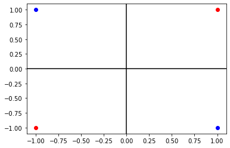

```python
import numpy as np

%matplotlib inline
import matplotlib.pyplot as plt

# input of the MLP
X = np.array([[1,1], [1,-1], [-1,-1], [-1,1]])
# output of the MLP
y = np.array([[0], [1], [0], [1]])

# plot the training data
fig, ax = plt.subplots()
for i in range(y.shape[0]):
  if y[i][0] == 0:
    marker = 'ro'
  else:
    marker = 'bo'
  ax.plot(X[i][0], X[i][1], marker)
ax.axhline(y=0, color='k')
ax.axvline(x=0, color='k')
```

This is how the training data looks like in a 2D plot. The red dot means the output label is 0, the blue dot means the output label is 1. Clearly, these data points are not linearly separable. We can not find one single line to classify the points correctly. We will thus build a multi-layer perceptron with nonlinearity to learn the right predictions.

### Activation functions

There are several activation functions to choose from, including sigmoid, tanh, relu, etc. Here, we implemented the sigmoid function as an example. In order to do backpropagation, we need to implement its derivative as well.

```python
# Sigmoid Function
def sigmoid(x):
    return 1 / (1 + np.exp(-x))

# Derivative of Sigmoid Function
def derivative_sigmoid(x):
    return x * (1 - x)
```

### Basic MLP architecture

The MLP consists of a hidden layer and an output layer to map the hidden vector to the output values. First, we initialize the weight and bias of each layer as well as the training epoch and learning rate.

```python
epoch = 5000 # number of training iterations
learning_rate = 0.1

# dimension of each layer
d_in = X.shape[1] # number of features in the input dataset
d_h = 3   # hidden layer
d_out = 1 # output layer

# weight and bias initialization
wh = np.random.uniform(size=(d_in, d_h))
bh = np.random.uniform(size=(1, d_h))
wout = np.random.uniform(size=(d_h, d_out))
bout = np.random.uniform(size=(1, d_out))
```

For each training iteration, we run one forward pass to get the predicted value and compute the loss between the prediction and the real value. For simplicity, we use the differences between the two values as the loss function. Then, we can compute the gradients and finally update the weights and biases.

```python
for i in range(epoch):
    # Forward pass
    h = sigmoid(X.dot(wh) + bh)
    y_pred = sigmoid(h.dot(wout) + bout)

    # Compute and print loss
    loss = (y_pred - y).sum()
    if i % 500 == 0:
        print('Epoch', i, ':', loss)

    # Backpropagation to compute gradients
    grad_y_pred = (y - y_pred) * derivative_sigmoid(y_pred)
    grad_wout = h.T.dot(grad_y_pred)
    grad_bout = np.sum(grad_y_pred, axis=0, keepdims=True)
    grad_h = grad_y_pred.dot(wout.T) * derivative_sigmoid(h)
    grad_wh = X.T.dot(grad_h)
    grad_bh = np.sum(grad_h, axis=0, keepdims=True)

    # Update weights and biases
    wout += grad_wout * learning_rate
    bout += grad_bout * learning_rate
    wh += grad_wh * learning_rate
    bh += grad_bh * learning_rate

print('Prediction of training data:')
print(y_pred)
```

```
Epoch 0 : 1.0602859352650642
Epoch 500 : 0.025402914789192543
Epoch 1000 : 0.05605838011622788
Epoch 1500 : 0.026988835757572882
Epoch 2000 : 0.02482175606867751
Epoch 2500 : 0.02004252992839914
Epoch 3000 : 0.0162610441646842
Epoch 3500 : 0.013706089531291848
Epoch 4000 : 0.011914983165429882
Epoch 4500 : 0.010599336571058396
Prediction of training data:
[[0.06360043]
 [0.93466673]
 [0.07101008]
 [0.94031849]]
```

The predicted values are very close to the labels in the training data. Since they are real values, to get the binary output, we can simply threshold the output to decide which label we want to assign.

### Building Model: Linear Regression

Now, we know how to do the basic computation using PyTorch. Let's start to build a simple linear regression model. First, we generate 100 x, y data points for training. The data points follow this formula: y = 3.0 * x + 1.0 The goal is to regress W and b that fits the training data.

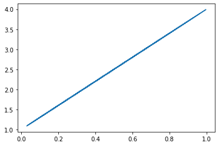

```python
import numpy as np
import matplotlib.pyplot as plt

x_train = np.random.rand(100).astype(np.float32).reshape(-1,1)
y_correct = 3.0 * x_train + 1.0

plt.plot(x_train, y_correct)
```

A model in PyTorch is a subclass of `nn.Module`. There are several predefined layers and containers in the [`torch.nn`](https://pytorch.org/docs/stable/nn.html) module. We can use those to build more complex network structures.

More complex neural networks are easily built using the predefined layers with the container classes `Sequential` and `Concat`.

The main method to implement in the `nn.Module` is `forward`. It computes the output of the model given the input Tensor. The computation we put here defines the network architecture and how data flows between layers.

A linear regression model is basically a single linear layer! We first define the layers we needed in `__init__` and then build the computation in `forward`.

```python
class LinearRegressionModel(nn.Module):

    def __init__(self, input_dim, output_dim):

        super(LinearRegressionModel, self).__init__()
        self.linear = nn.Linear(input_dim, output_dim)

    def forward(self, x):
        out = self.linear(x)
        return out
```

We then instantiate the model for training. We will use the mean squared error ([`nn.MSELoss`](https://pytorch.org/docs/stable/nn.html#torch.nn.MSELoss)) as loss function and optimize the network with stochastic gradient descent ([`torch.optim.SGD`](https://pytorch.org/docs/stable/optim.html#torch.optim.SGD)).

We need to specify the parameters we want to optimize in the first argument of the selected optimizer. Usually, this should be all parameters in the model.

```python
model = LinearRegressionModel(1, 1)

criterion = nn.MSELoss()
learing_rate = 0.01
optimizer = torch.optim.SGD(model.parameters(), lr=learing_rate)

epochs = 2000
```

Similar to what we did in the numpy example, at each training iteration, we perform one forward pass, get the loss, compute the gradients (using `.backward()`), and update the parameters by taking a `.step()` with the optimizer.

**Note** that we need to clear the gradients that are accumulated from previous training iterations first so we don't optimize against the old gradients stored in the variables. We can easily do this by calling `optimizer.zero_grad()` at the beginning of each iteration.

```python
for epoch in range(epochs):
    inputs = torch.from_numpy(x_train)
    labels = torch.from_numpy(y_correct)

    optimizer.zero_grad()
    outputs = model.forward(inputs)
    loss = criterion(outputs, labels)
    loss.backward()
    optimizer.step()
    if epoch % 100 == 0:
        print('epoch {}, loss {}'.format(epoch, loss.item()))
```

```
epoch 0, loss 2.7053091526031494
epoch 100, loss 0.2665365934371948
epoch 200, loss 0.19683608412742615
epoch 300, loss 0.15556463599205017
epoch 400, loss 0.12302804738283157
epoch 500, loss 0.09729723632335663
epoch 600, loss 0.0769478902220726
epoch 700, loss 0.060854583978652954
epoch 800, loss 0.04812697321176529
epoch 900, loss 0.03806151822209358
epoch 1000, loss 0.03010110929608345
epoch 1100, loss 0.02380559965968132
epoch 1200, loss 0.018826713785529137
epoch 1300, loss 0.01488919835537672
epoch 1400, loss 0.011775204911828041
epoch 1500, loss 0.0093124620616436
epoch 1600, loss 0.0073648374527692795
epoch 1700, loss 0.005824500694870949
epoch 1800, loss 0.004606310278177261
epoch 1900, loss 0.003642922965809703
```

After the model is trained, we can apply the forward method to get the prediction for any data point. We can also visualize the result to see what the predictions look like.

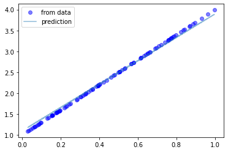

```python
predicted = model.forward(torch.from_numpy(x_train)).data.numpy()

plt.plot(x_train, y_correct, 'bo', label='from data', alpha=0.5)
plt.plot(x_train, predicted, label='prediction', alpha=0.5)
plt.legend()
```

In case anything goes wrong and you want to check the learned parameters of your model, you can inspect the `weight` and `bias` of a layer as follows.

```python
print(model.linear.weight)
print(model.linear.bias)
```

```
Parameter containing:
tensor([[2.7996]], requires_grad=True)
Parameter containing:
tensor([1.0947], requires_grad=True)
```

### Exercise 1: Variant of XOR Problem

Here we will build our variant of the XOR classifier. We will use data points ranging between -10 and 10 for trainig.

```python
import random
random.seed(1)

x_train = []
y_correct = []
for i in range(100):
    x0 = random.randint(-10, 10)
    x1 = random.randint(-10, 10)
    label = 0 if x0 * x1 > 0 else 1
    x_train.append([x0, x1])
    y_correct.append(label)
x_train = np.asarray(x_train)
y_correct = np.asarray(y_correct)
```

Next, try to implement the structure of the classifier. You can use the architecture in our first example, which consists of a hidden and an output linear layer.

To apply sigmoid function, you can use [`torch.sigmoid`](https://pytorch.org/docs/stable/torch.html#torch.sigmoid).

```python
class XorClassifier(nn.Module):

    def __init__(self, input_dim, output_dim):

        super(XorClassifier, self).__init__()
        # TODO: please initialize the layers here
        self.input_layer = nn.Linear(input_dim, 10)
        self.output_layer = nn.Linear(10, output_dim)

    def forward(self, x):
        # TODO: please build your forward pass here
        input = torch.sigmoid(self.input_layer(x))
        out = torch.sigmoid(self.output_layer(input))
        return out
```

In the XOR variant, differently from what we did before, we get the network to output two values to indicate the probability distribution over the two possible labels instead of one real value.

So, we set the output dimension to 2 and use cross-entropy as loss function ([`nn.CrossEntropyLoss()`](https://pytorch.org/docs/stable/nn.html#torch.nn.CrossEntropyLoss)) because it is useful when training a classification problem with N classes.

We also try a different optimizer this time. Adam is an adaptive optimization algorithm. You can try to compare Adam with SGD as well!

```python
model = XorClassifier(2, 2)

criterion = nn.CrossEntropyLoss()
learning_rate = 0.01
optimizer = torch.optim.Adam(model.parameters(), lr=learning_rate)

epochs = 5000
```

Let's complete the final part of the training script to learn the classifier.

```python
for epoch in range(epochs):
    inputs = torch.from_numpy(x_train).type(torch.FloatTensor)
    labels = torch.from_numpy(y_correct).long()

    # TODO: please complete the training script
    optimizer.zero_grad()
    outputs = model.forward(inputs)
    loss = criterion(outputs, labels)
    loss.backward()
    optimizer.step()

    if epoch % 500 == 0:
        print('epoch {}, loss {}'.format(epoch, loss.item()))
```

```
epoch 0, loss 0.3137979805469513
epoch 500, loss 0.3136635720729828
epoch 1000, loss 0.3135640621185303
epoch 1500, loss 0.3134908974170685
epoch 2000, loss 0.3134365379810333
epoch 2500, loss 0.3133957087993622
epoch 3000, loss 0.31336474418640137
epoch 3500, loss 0.3133411407470703
epoch 4000, loss 0.313323050737381
epoch 4500, loss 0.31330910325050354
```

Since we're predicting the distribution over the labels, we need to take the index of the max value as the predicted label. Then, we can draw the predictions in a 2D plot. If your model learns well, you will see that most dots in the 1st and 3rd quadrants are red, and most dots in the 2nd and 4th quadrants are blue.

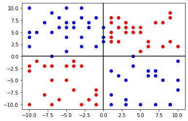

```python
outputs = model.forward(torch.from_numpy(x_train).type(torch.FloatTensor))
_, predicted = torch.max(outputs, 1)

fig, ax = plt.subplots()
for i in range(y_correct.shape[0]):
    if predicted[i] == 0:
        marker = 'ro'
    else:
        marker = 'bo'
    ax.plot(x_train[i][0], x_train[i][1], marker)
ax.axhline(y=0, color='k')
ax.axvline(x=0, color='k')
```

### Exercise 2:

Consider what might happen if you attempted to solve the original XOR problem (with 4 examples) using a network with no hidden layer and a single linear output neuron.

What would be the simplest modification you'd make to the architecture of the above network, such as adding one or two hidden neurons, in order to learn the XOR problem?

### Extra: MNIST classification

**Dataset**

- MNIST dataset.
- There are 28*28 images and 10 labels from 0 to 9.
- Data is not normalized so we divide each image to 255 that is basic normalization for images.
- In order to split data, we use **train_test_split** method from sklearn library
- Size of train data is 80% and size of test data is 20%.
- Create **feature** and **target tensors**.
- **TensorDataset()**: Data set wrapping tensors. Each sample is retrieved by indexing tensors along the first dimension.
- **DataLoader()**: It combines dataset and sampler. It also provides multi process iterators over the dataset.

**ANN Model**

- We add 3 hidden layers.
- We use ReLU, Tanh and ELU activation functions for variety.

**Model Class**

**Loss Class**

- Cross entropy loss
- It has softmax(logistic function) in it.

**Optimizer Class**

- SGD Optimizer

**Traning the Model**

**Prediction**

```python
import numpy as np
import matplotlib.pyplot as plt
```

```python
import torch
import torch.nn as nn
import torchvision.transforms as transforms
from torch.autograd import Variable
import pandas as pd
from sklearn.model_selection import train_test_split
```

```python
train = pd.read_csv("train.csv",dtype = np.float32)

# split data into features(pixels) and labels(numbers from 0 to 9)
targets_numpy = train.label.values
features_numpy = train.loc[:,train.columns != "label"].values/255 # normalization

# train test split. Size of train data is 80% and size of test data is 20%.
features_train, features_test, targets_train, targets_test = train_test_split(features_numpy,
                                                                             targets_numpy,
                                                                             test_size = 0.2,
                                                                             random_state = 42)

# create feature and targets tensor for train set. We need variable to accumulate gradients.
featuresTrain = torch.from_numpy(features_train)
targetsTrain = torch.from_numpy(targets_train).type(torch.LongTensor) # data type is long

# create feature and targets tensor for test set.
featuresTest = torch.from_numpy(features_test)
targetsTest = torch.from_numpy(targets_test).type(torch.LongTensor) # data type is long

# batch_size, epoch and iteration
batch_size = 100
n_iters = 10000
num_epochs = n_iters / (len(features_train) / batch_size)
num_epochs = int(num_epochs)

# Pytorch train and test sets
train = torch.utils.data.TensorDataset(featuresTrain,targetsTrain)
test = torch.utils.data.TensorDataset(featuresTest,targetsTest)

# data loader
train_loader = torch.utils.data.DataLoader(train, batch_size = batch_size, shuffle = False)
test_loader = torch.utils.data.DataLoader(test, batch_size = batch_size, shuffle = False)

# visualize one of the images in data set
plt.imshow(features_numpy[10].reshape(28,28))
plt.axis("off")
plt.title(str(targets_numpy[10]))
plt.savefig('graph.png')
plt.show()
```

[output not shown]

```python
# ANN Model
class ANNModel(nn.Module):
    def __init__(self, input_dim, hidden_dim, output_dim):
        super(ANNModel, self).__init__()
        self.fc1 = nn.Linear(input_dim, hidden_dim)
        self.relu1 = nn.ReLU()

        self.fc2 = nn.Linear(hidden_dim, hidden_dim)
        self.tanh2 = nn.Tanh()

        self.fc3 = nn.Linear(hidden_dim, hidden_dim)
        self.elu3 = nn.ELU()

        self.fc4 = nn.Linear(hidden_dim, output_dim)

    def forward(self, x):

        out = self.fc1(x)

        out = self.relu1(out)


        out = self.fc2(out)

        out = self.tanh2(out)


        out = self.fc3(out)

        out = self.elu3(out)


        out = self.fc4(out)
        return out
```

```python
# instantiate ANN
input_dim = 28*28
hidden_dim = 150
output_dim = 10
```

```python
# Create ANN
model = ANNModel(input_dim, hidden_dim, output_dim)
```

```python
# Cross Entropy Loss
error = nn.CrossEntropyLoss()
```

```python
# SGD Optimizer
learning_rate = 0.02
optimizer = torch.optim.SGD(model.parameters(), lr=learning_rate)
```

```python
# ANN model training
count = 0
loss_list = []
iteration_list = []
accuracy_list = []
for epoch in range(num_epochs):
    for i, (images, labels) in enumerate(train_loader):

        train = Variable(images.view(-1, 28*28))
        labels = Variable(labels)

        # Clear gradients
        optimizer.zero_grad()

        # Forward propagation
        outputs = model(train)

        # Calculate softmax and ross entropy loss
        loss = error(outputs, labels)

        # Calculating gradients
        loss.backward()

        # Update parameters
        optimizer.step()

        count += 1

        if count % 50 == 0:
            # Calculate Accuracy
            correct = 0
            total = 0
            # Predict test dataset
            for images, labels in test_loader:

                test = Variable(images.view(-1, 28*28))

                # Forward propagation
                outputs = model(test)

                # Get predictions from the maximum value
                predicted = torch.max(outputs.data, 1)[1]

                # Total number of labels
                total += len(labels)

                # Total correct predictions
                correct += (predicted == labels).sum()

            accuracy = 100 * correct / float(total)

            # store loss and iteration
            loss_list.append(loss.data)
            iteration_list.append(count)
            accuracy_list.append(accuracy)
            if count % 500 == 0:
                # Print Loss
                print('Iteration: {}  Loss: {}  Accuracy: {} %'.format(count, loss.data, accuracy))
```

[output not shown]

```python
# visualization loss
plt.plot(iteration_list,loss_list)
plt.xlabel("Number of iteration")
plt.ylabel("Loss")
plt.title("ANN: Loss vs Number of iteration")
plt.show()

# visualization accuracy
plt.plot(iteration_list,accuracy_list,color = "red")
plt.xlabel("Number of iteration")
plt.ylabel("Accuracy")
plt.title("ANN: Accuracy vs Number of iteration")
plt.show()
```

[output not shown]